# 03 - Formatting ggplots

John Shorter

Feb/16/2026

Codes are highlighted in `grey`.

# Introduction

We’ll use the R built-in dataset “ToothGrowth”. This dataset is about different doses of vitamin C on tooth growth of guinea pigs.

Ref: Crampton, E. W (1947). The Journal of Nutrition, 33(5), 491–504. doi: 10.1093/jn/33.5.491.

```r
head(ToothGrowth)
```

```
##    len supp dose
## 1  4.2   VC  0.5
## 2 11.5   VC  0.5
## 3  7.3   VC  0.5
## 4  5.8   VC  0.5
## 5  6.4   VC  0.5
## 6 10.0   VC  0.5
```

```r
str(ToothGrowth)
```

```
## 'data.frame':    60 obs. of  3 variables:
##  $ len : num  4.2 11.5 7.3 5.8 6.4 10 11.2 11.2 5.2 7 ...
##  $ supp: Factor w/ 2 levels "OJ","VC": 2 2 2 2 2 2 2 2 2 2 ...
##  $ dose: num  0.5 0.5 0.5 0.5 0.5 0.5 0.5 0.5 0.5 0.5 ...
```

It has 60 rows and 3 columns. Two types of supp: “OJ” and “VC”. Looks like “len” is tooth length and the dependent variable.

Let’s make the most basic plots first. We can use some commands in base R to look at the data

## We can ask R to plot all the elements by entering the data set name with the plot function.

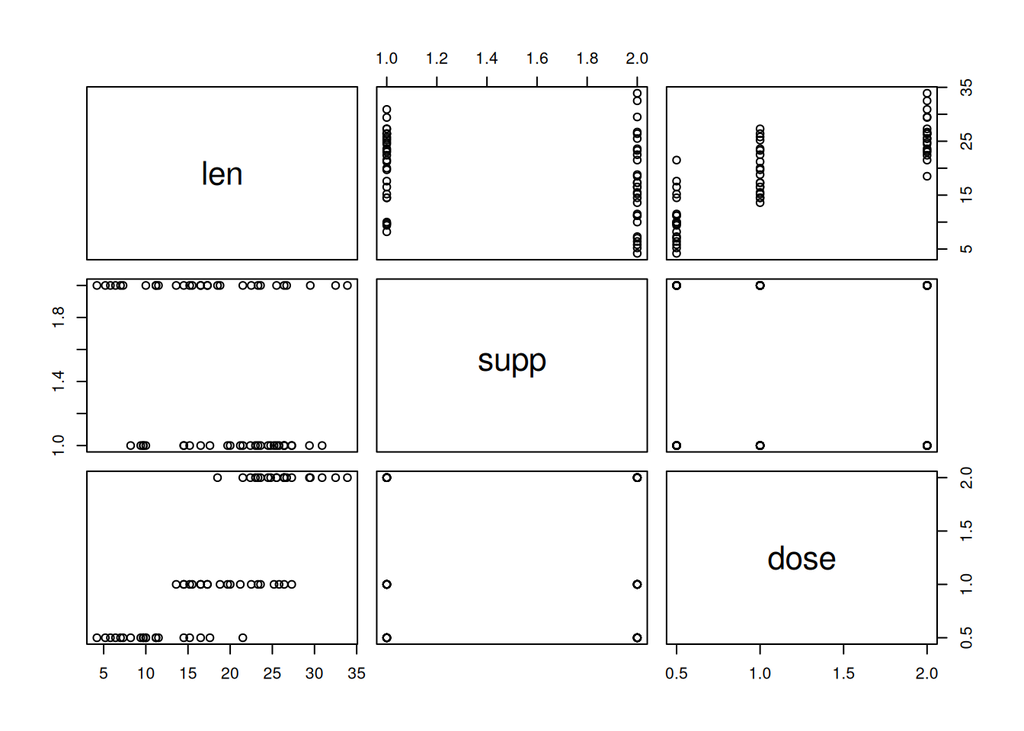

```r
plot(ToothGrowth)
```

## We can make specific plots by telling it what to put on the Y and X axes by using the $.

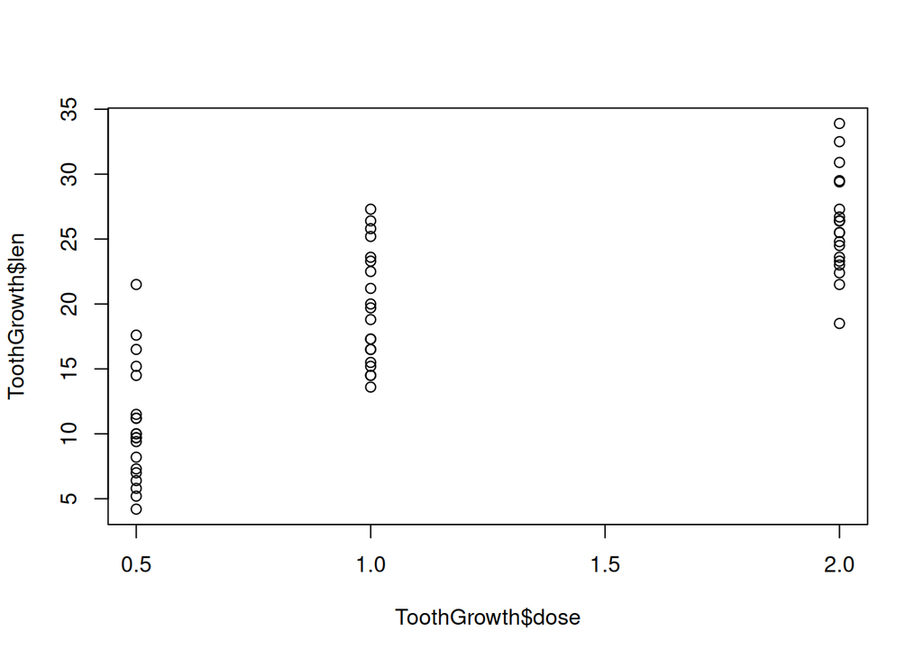

```r
plot(ToothGrowth$dose, ToothGrowth$len)
```

## We can make histograms to look at data distribution as well. Often a good place to start with a new data set.

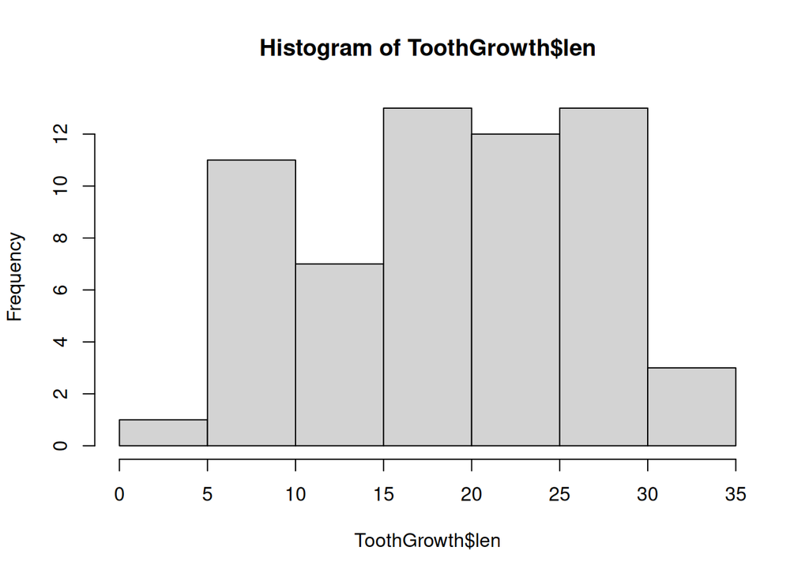

```r
hist(ToothGrowth$len)
```

However, we can make better plots and figures! The ggplot package in R is a powerful plotting tool. It’s easy to use, but you can make complex plots with rather simple syntax.

“gg” stands for graphical grammar. It means different layers of objects and elements are layered on top of the previous to generate the plot. You can find the [ggplot cheatsheet](https://raw.githubusercontent.com/rstudio/cheatsheets/main/data-visualization.pdf) And in the help menu under Cheat Sheets.

This module will go over different features of ggplot

1. geoms
2. scales
3. guides
4. themes
5. facets

…and how to make the clearest, prettiest ggplot possible.

# Load packages

You might need to install some of these packages

```r
library(ggplot2)
library(tidyr)
library(dplyr)
```

# Coordinate system in ggplot

Understanding the syntax of ggplot is the most important thing! Dose on X, length on Y, color as supp for this dataset.

```r
ggplot(data = ToothGrowth) +
  geom_point(mapping = aes(x = dose, y = len, color = supp))
```

[output not shown]

The line `ggplot(data = ...)` specifies the data file. It doesn’t do much by itself. Try it if you don’t believe me!

Then you add a new layer (in this case points) by using `+`and in a new line you write `geom_point()`. “Geom” stands for geometric objects. In this case `geom_points()` produces points.

The mapping argument is always paired with aesthetics `aes()`, and the x and y arguments of `aes()` specify which variables to map to the x and y axes. ggplot2 looks for the mapped variables in the data argument.

Then to color by supp, you write `aes(.... , color = supp)`.

We can also save the plot and print it. Notice it now appears in your environment.

```r
example1 = ggplot(data = ToothGrowth) +
  geom_point(mapping = aes(x = dose, y = len, color = supp))

example1
```

[output not shown]

Here is another way to make the same plot! This is using the %>%. There are many different ways to get to the same outcome.

```r
ToothGrowth %>%
  ggplot(aes(x = dose, y = len)) +
  geom_point(aes(color = supp))
```

[output not shown]

I prefer to type out the data frame first, then pipe into `ggplot()`. It’s more readable this way. No need to specify data = blah and mapping = blah. Thus `ToothGrowth %>% ggplot(...)`

These plots are not bad… Now let’s use a custom palette called “wisteria”. It’s just a set of color names.

# Adjust geom color/fill

```r
wisteria <- c("grey65", "burlywood3", "khaki2", "plum1", "lightcyan2", "cornflowerblue", "slateblue3")
```

This is just a list of color names in R.

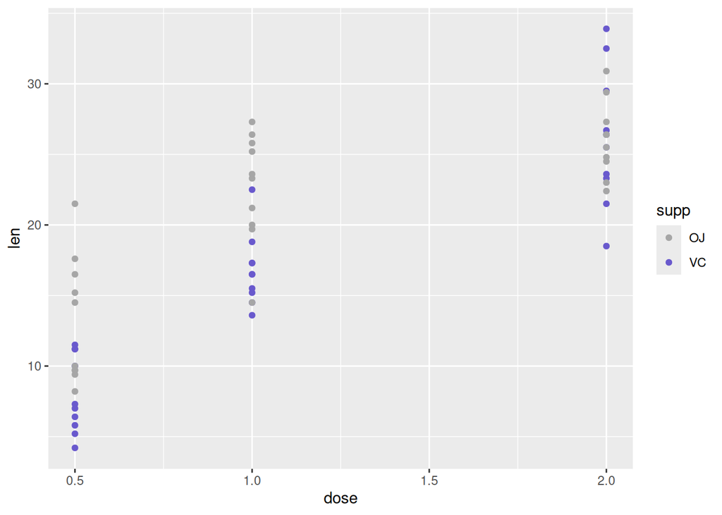

```r
ToothGrowth %>%
  ggplot(aes(x = dose, y = len)) +
  geom_point(aes(color = supp)) +
  scale_color_manual(values = wisteria[c(1, 7)]) # calling the 1st and 7th color
```

You can customize color using `scale_color_manual()`, inside which, you specifies the names of the colors, in this case the color names are pre-specified by a vector called `wisteria`.

# Change axis and legend labels - labs()

Now I want to change the axis and legend titles. How do I do that?

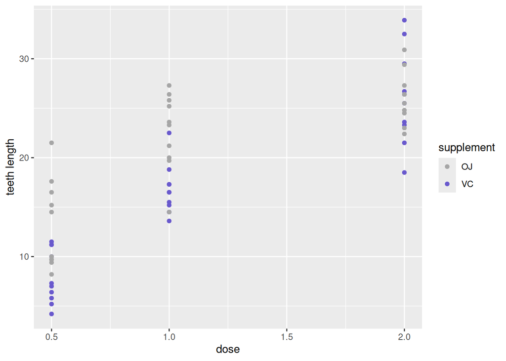

```r
ToothGrowth %>%
  ggplot(aes(x = dose, y = len)) +
  geom_point(aes(color = supp)) +
  scale_color_manual(values = wisteria[c(1, 7)]) +
  labs(x = "dose",              # the labs option allow you to change axis and legend labels.
       y = "teeth length",
       color = "supplement")
```

The `labs()` function allows you to change axis and legend labels.

You can see the dots are overlapping each other. How do I make them spread out a bit horizontally?

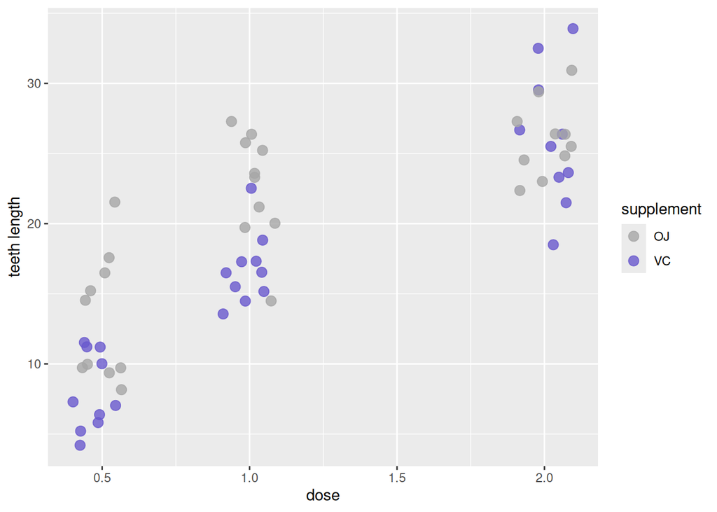

```r
ToothGrowth %>%
  ggplot(aes(x = dose, y = len)) +
  geom_point(aes(color = supp),
             position = position_jitter(0.1),   #horizontal spread of 0.1
             alpha = 0.8,             # 20% transparent. When dots do overlap, we can tell
             size = 3) +    # make them larger and easier to see
  scale_color_manual(values = wisteria[c(1, 7)]) +
  labs(x = "dose",
       y = "teeth length",
       color = "supplement")
```

There are a few options in geom_points. The `position = position_jitter(0.1)` argument adds random horizontal spread of 0.1 to each dot. The `alpha = 0.8` makes your dots 20% transparent. (`alpha = 1` is 0% transparent and default.) The `size` option allows you to make dots larger or smaller.

This is great, but I can make it even better by adding border to each dots. How to do that?

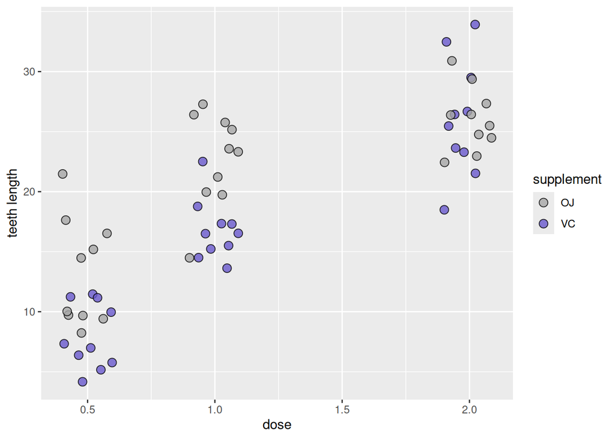

```r
ToothGrowth %>%
  ggplot(aes(x = dose, y = len)) +
  geom_point(aes(fill = supp), # note that change to fill = supp
             position = position_jitter(0.1),
             alpha = 0.8,
             size = 3,
             shape = 21, # shape = 21 gives you open circle
             color = "black") +    # black border around each dot
  scale_fill_manual(values = wisteria[c(1, 7)]) + # change to scale_fill here
  labs(x = "dose",
       y = "teeth length",
       fill = "supplement") # change to fill = here
```

`shape = 21` inside `geom_point()` creates hollow dots. `color = "black"` adds black borders to each dot. Now the color of the dots are control by `fill` inside of `color`, which I will explain below.

## Color vs fill

Well there are more options in `geom_point()`. One of them is shape. `geom_point` allows different shapes, such as square, cross and etc. My favorite is open circle. To use the open circles, you call `shape = 21`. The advantage of open circle is that it has both `color` and `fill` properties. To help you understand the difference between color and fill, let’s compare the following two plots.

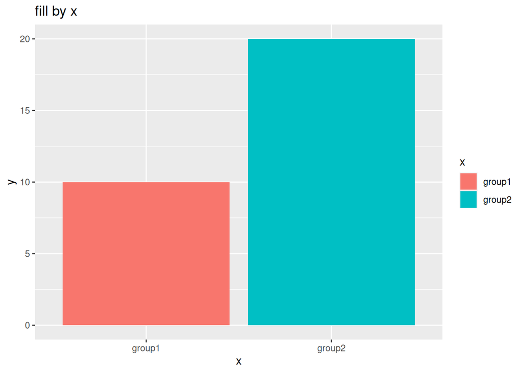

```r
data.frame(
  x = c("group1", "group2"),
  y = c(10, 20)
) %>%
  ggplot(aes(x = x, y = y)) +
  geom_bar(stat = "identity", aes(fill = x)) +
  ggtitle("fill by x")
```

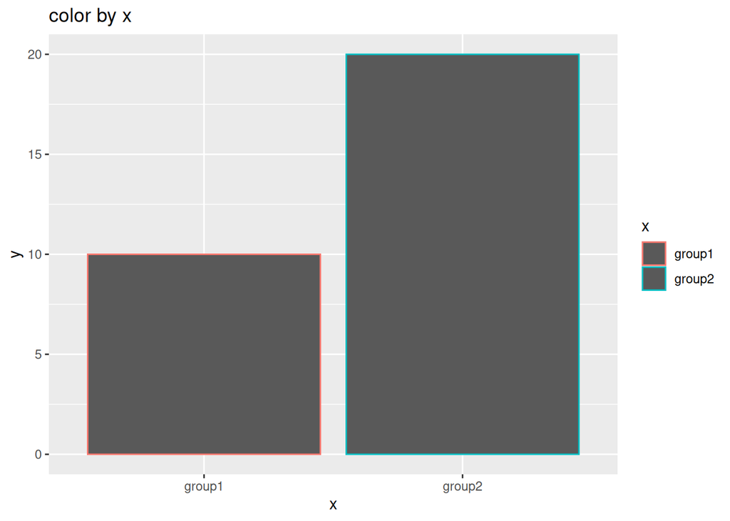

```r
data.frame(
  x = c("group1", "group2"),
  y = c(10, 20)
) %>%
  ggplot(aes(x = x, y = y)) +
  geom_bar(stat = "identity", aes(color = x)) +
  ggtitle("color by x")
```

I hope you can see the difference. If we use `fill`, the entire interior is colored, or filled. If we use `color`, only the outline is colored.

Coming back to using open circles in `geom_point()`, Open circles takes both `fill` and `color`.

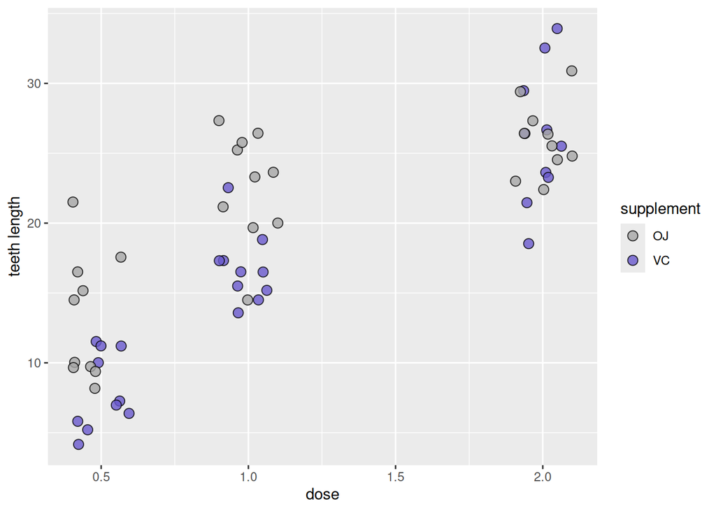

```r
ToothGrowth %>%
  ggplot(aes(x = dose, y = len)) +
  geom_point(aes(fill = supp), #note that change to fill = supp
             position = position_jitter(0.1),
             alpha = 0.8,
             size = 3,
             shape = 21, # shape = 21 gives you open circle
             color = "black") +    # black border around each dot
  scale_fill_manual(values = wisteria[c(1, 7)]) + # change to scale_fill here
  labs(x = "dose",
       y = "teeth length",
       fill = "supplement") # change to fill = here
```

In this case, I use `color = "black"` to make black outlines for each dot. Then I used `aes(fill = supp)` to fill the interior of dots by the supp. Now, to specify colors, I have to use `scale_fill_manual()`, instead of `scale_color_manual()`, because the variable `supp` is now reflected by fill, not color.

But there is still a problem… Note that when you use jitter, the horizontal spread is completely random. This means every time you run the code, the position of the dots are different. How do I fix that? You can add a `seed` argument within `position_jitter()`, that will make it reproducible.

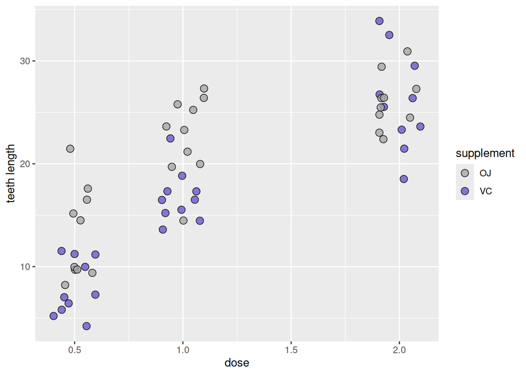

```r
ToothGrowth %>%
  ggplot(aes(x = dose, y = len)) +
  geom_point(aes(fill = supp),
             position = position_jitter(0.1, seed = 666),   #added seed = 666 here. My favorite number.
                                                    #doesn't matter which seed number you use
                                                    #as long as it's the same number the pattern will be the same
             alpha = 0.8,
             size = 3,
             shape = 21,
             color = "black") +
  scale_fill_manual(values = wisteria[c(1, 7)]) +
  labs(x = "dose",
       y = "teeth length",
       fill = "supplement")
```

In this case, I used `seed = 666`. My favorite number. But you can use any seed number. As long as it’s the same number, the plot will look the same every time you run the code.

# Stat_summary - very powerful visualization tool

Let’s say I want a curve for each supplement, what should I do? Your first reaction is `geom_line()`, no?

Unfortunately, that’s not the right answer. `geom_line` will try to connect each dot, but what we want is try to connect the *means* of each dose for each supp. We’ll use `stat_summary()` instead.

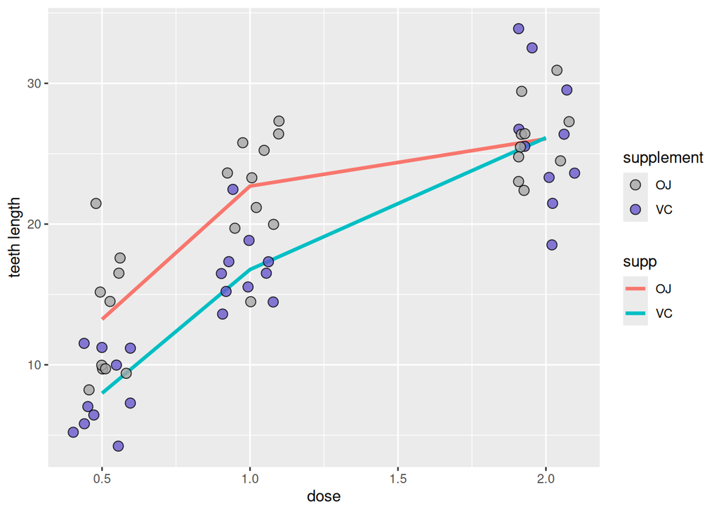

```r
ToothGrowth %>%
  ggplot(aes(x = dose, y = len)) +
  stat_summary(geom = "line",  # draw a line
               fun = mean, # summarise by averaging, thus mean
               aes(group = supp, color = supp), # one line per supp, color by supp
               linewidth = 1.2) +
  geom_point(aes(fill = supp),
             position = position_jitter(0.1, seed = 666),
             alpha = 0.8,
             size = 3,
             shape = 21,
             color = "black") +
  scale_fill_manual(values = wisteria[c(1, 7)]) +
  labs(x = "dose",
       y = "teeth length",
       fill = "supplement")
```

In `stat_summary()`, I put `geom = "line"`, which asked it to draw lines. Then I put `fun = mean`, which asked it summarize y values using the `mean()` function. Then I put `aes(group = supp, color = supp)`, which asked for one line per supp, and color those lines by supp.

Well, there’s a problem. The lines are not the same color as the dots. That’s because we specified the interior colors of dots using `scale_fill_manual()`, but we never specified the color of the lines. It’s easy to fix. We will use `scale_color_manual()` to specify colors for the lines too.

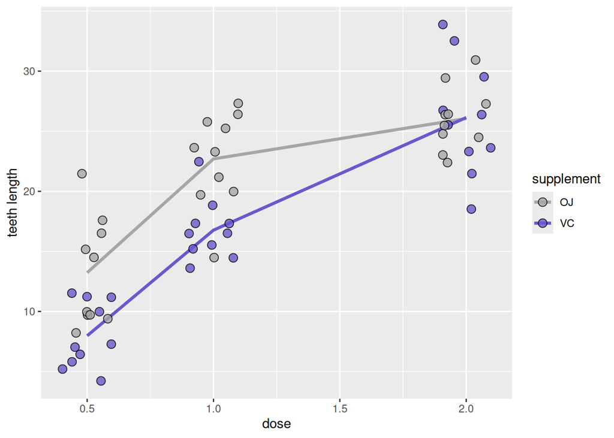

```r
ToothGrowth %>%
  ggplot(aes(x = dose, y = len)) +
  stat_summary(geom = "line",
               fun = mean,
               aes(group = supp, color = supp),
               linewidth = 1.2) +
  geom_point(aes(fill = supp),
             position = position_jitter(0.1, seed = 666),
             alpha = 0.8,
             size = 3,
             shape = 21,
             color = "black") +
  scale_fill_manual(values = wisteria[c(1, 7)]) +
  scale_color_manual(values = wisteria[c(1, 7)]) + #add scale_color_manual here
  labs(x = "dose",
       y = "teeth length",
       fill = "supplement",
       color = "supplement") #change the color legend title here
```

Better! Note that since the title and scales of fill and color are the same, ggplot merged them in the legend.

Now I want to add errorbars to the line, how do I do that? We’ll use `stat_summary` again, but this time instead of `geom = "line"`, we’ll do `geom = "errorbar"`. Besides `geom = "errorbar"`, another option is `geom = "linerange"`. “linerange” is errorbar without the horizontal bars.

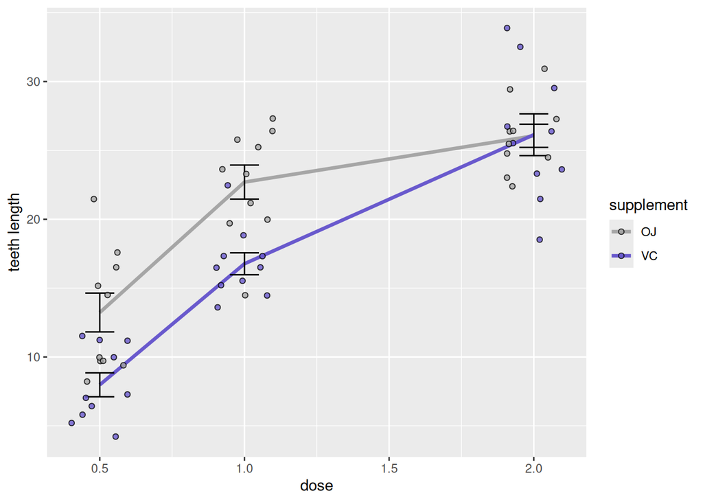

```r
ToothGrowth %>%
  ggplot(aes(x = dose, y = len)) +
  stat_summary(geom = "line",
               fun = mean,
               aes(group = supp, color = supp),
               linewidth = 1.2) +
  stat_summary(geom = "errorbar",  # draw error bars (another option is geom = "linerange")
               fun.data = mean_se, # mean_se specifies the error bar to be based on standard error (se)
               aes(group = supp), # one errorbar per dose per supp
               width = 0.1) +   # make the bar narrower
  geom_point(aes(fill = supp),
             position = position_jitter(0.1, seed = 666),
             alpha = 0.8,
             linewidth = 3,
             shape = 21,
             color = "black") +
  scale_fill_manual(values = wisteria[c(1, 7)]) +
  scale_color_manual(values = wisteria[c(1, 7)]) +
  labs(x = "dose",
       y = "teeth length",
       fill = "supplement",
       color = "supplement")
```

Now there are error bars. Here is another option to show the errorbar using `stat_summary(geom = "ribbon")`. I like ribbon better. You can see for yourself.

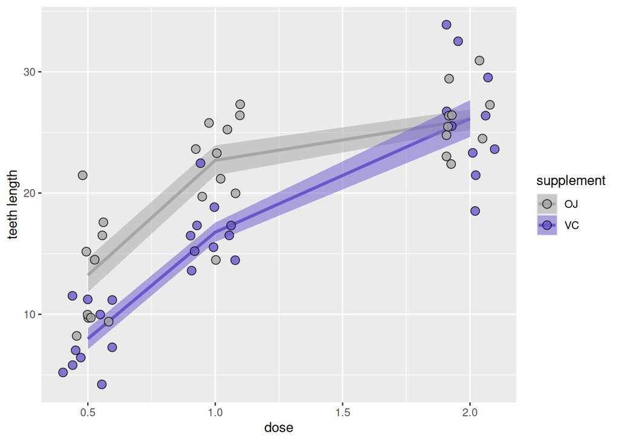

```r
ToothGrowth %>%
  ggplot(aes(x = dose, y = len)) +
  stat_summary(geom = "line",
               fun = mean,
               aes(group = supp, color = supp),
               linewidth = 1.2) +
  stat_summary(geom = "ribbon",  #draw ribbons around line
               fun.data = mean_se,
               aes(group = supp,
                   fill = supp),
               alpha = 0.5) +   #make ribbons more transparent
  geom_point(aes(fill = supp),
             position = position_jitter(0.1, seed = 666),
             alpha = 0.8,
             size = 3,
             shape = 21,
             color = "black") +
  scale_fill_manual(values = wisteria[c(1, 7)]) +
  scale_color_manual(values = wisteria[c(1, 7)]) +
  labs(x = "dose",
       y = "teeth length",
       fill = "supplement",
       color = "supplement")
```

I like the ribbon better. It looks very nice for high transparency with `alpha = 0.5`. But feel free to use errorbar or linerange if you prefer those.

# Adjust legends and axis

Note that in the experiment, there’s never a dose = 1.5. We can turn off the x axis tick mark of 1.5 by using `scale_x`. (You can adjust y axis using `scale_y` as well, if you ever need to).

BTW, if you ever need to log10 transform axis, you can do `scale_x_log10()` or `scale_y_log10()`

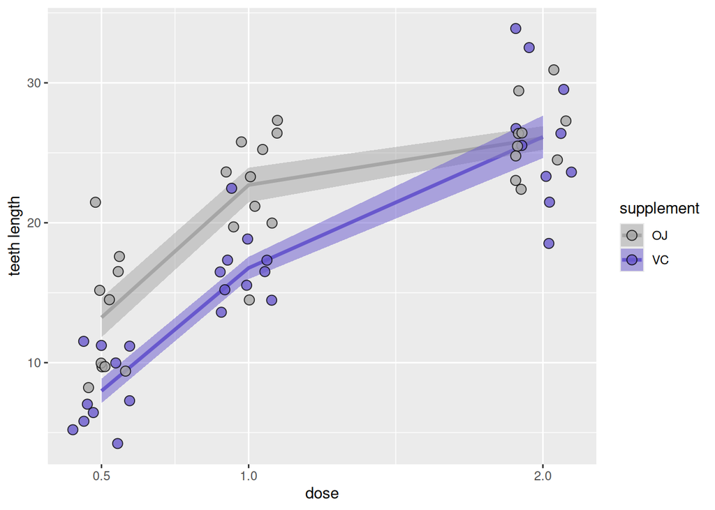

```r
ToothGrowth %>%
  ggplot(aes(x = dose, y = len)) +
  stat_summary(geom = "line",
               fun = mean,
               aes(group = supp, color = supp),
               linewidth = 1.2) +
  stat_summary(geom = "ribbon",
               fun.data = mean_se,
               aes(group = supp,
                   fill = supp),
               alpha = 0.5) +
  geom_point(aes(fill = supp),
             position = position_jitter(0.1, seed = 666),
             alpha = 0.8,
             size = 3,
             shape = 21,
             color = "black") +
  scale_fill_manual(values = wisteria[c(1, 7)]) +
  scale_color_manual(values = wisteria[c(1, 7)]) +
  scale_x_continuous(breaks = c(0.5, 1, 2)) + #use scale_x_continuous here because x is continuous
                                              #if you have discrete x, you will need scale_x_discrete
  labs(x = "dose",
       y = "teeth length",
       fill = "supplement",
       color = "supplement")
```

Because x axis value is numeric and continuous, you will use `scale_x_continuous()`. And inside, you set the break makers, in this case 0.5, 1 and 2. Now the x = 1.5 mark is turned off.

I realized the color and fill scales are redundant, so we can turn off one of them. To do so, we’ll use guides.

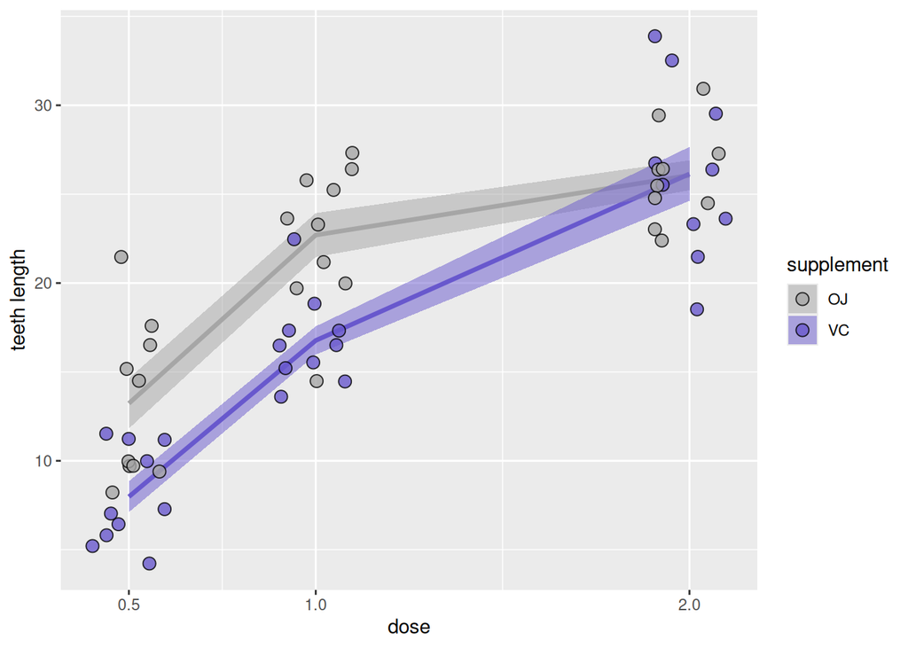

```r
ToothGrowth %>%
  ggplot(aes(x = dose, y = len)) +
  stat_summary(geom = "line",
               fun = mean,
               aes(group = supp, color = supp),
               linewidth = 1.2) +
  stat_summary(geom = "ribbon",
               fun.data = mean_se,
               aes(group = supp,
                   fill = supp),
               alpha = 0.5) +
  geom_point(aes(fill = supp),
             position = position_jitter(0.1, seed = 666),
             alpha = 0.8,
             size = 3,
             shape = 21,
             color = "black") +
  scale_fill_manual(values = wisteria[c(1, 7)]) +
  scale_color_manual(values = wisteria[c(1, 7)]) +
  scale_x_continuous(breaks = c(0.5, 1, 2)) +
  labs(x = "dose",
       y = "teeth length",
       fill = "supplement",
       color = "supplement") +
  guides(color = "none") #turn off color legend using color = "none"
```

The `guides()` function can do a lot of stuff. Here I turned color legend off by putting `color = "none"` in `guides()`.

# Adjust themes

The default theme is nice, but it’s not the best. You can use the `theme()` function to build your own theme.

We can remove all the theme element first using `theme_minimal()`

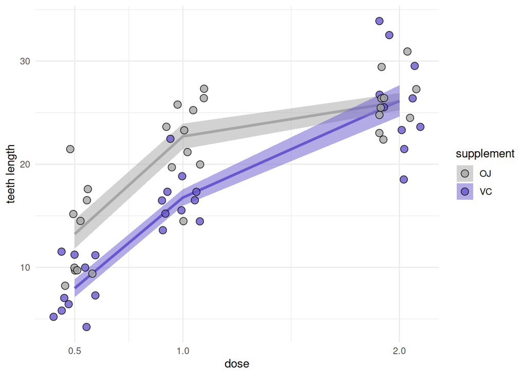

```r
ToothGrowth %>%
  ggplot(aes(x = dose, y = len)) +
  stat_summary(geom = "line",
               fun = mean,
               aes(group = supp, color = supp),
               linewidth = 1.2) +
  stat_summary(geom = "ribbon",
               fun.data = mean_se,
               aes(group = supp,
                   fill = supp),
               alpha = 0.5) +
  geom_point(aes(fill = supp),
             position = position_jitter(0.1, seed = 666),
             alpha = 0.8,
             size = 3,
             shape = 21,
             color = "black") +
  scale_fill_manual(values = wisteria[c(1, 7)]) +
  scale_color_manual(values = wisteria[c(1, 7)]) +
  scale_x_continuous(breaks = c(0.5, 1, 2)) +
  labs(x = "dose",
       y = "teeth length",
       fill = "supplement",
       color = "supplement") +
  guides(color = "none") +
  theme_minimal()
```

Theme minimal is the minimalist theme. It turns off most theme elements. But you can add elements that you want back.

Another common one is theme_bw(). Try it! what do you prefer? Here are some others https://ggplot2.tidyverse.org/reference/ggtheme.html

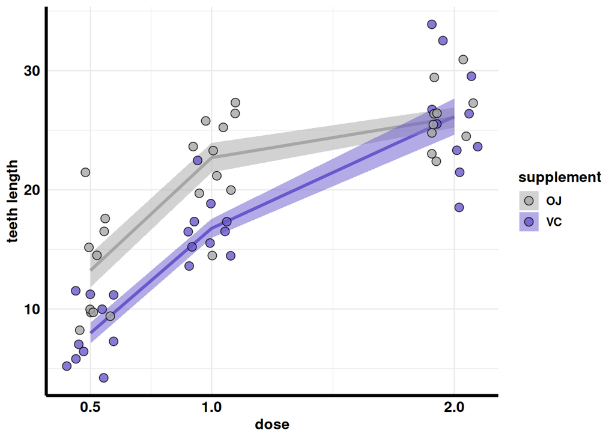

```r
ToothGrowth %>%
  ggplot(aes(x = dose, y = len)) +
  stat_summary(geom = "line",
               fun = mean,
               aes(group = supp, color = supp),
               linewidth = 1.2) +
  stat_summary(geom = "ribbon",
               fun.data = mean_se,
               aes(group = supp,
                   fill = supp),
               alpha = 0.5) +
  geom_point(aes(fill = supp),
             position = position_jitter(0.1, seed = 666),
             alpha = 0.8,
             size = 3,
             shape = 21,
             color = "black") +
  scale_fill_manual(values = wisteria[c(1, 7)]) +
  scale_color_manual(values = wisteria[c(1, 7)]) +
  scale_x_continuous(breaks = c(0.5, 1, 2)) +
  labs(x = "dose",
       y = "teeth length",
       fill = "supplement",
       color = "supplement") +
  guides(color = "none") +
  theme_minimal() +
  theme(
    axis.line = element_line(linewidth = 1.2), # add axis line back
    text = element_text(size = 12, color = "black", face = "bold"), # make text clearer and darker
    axis.text = element_text(size = 12, color = "black", face = "bold")
    )
```

The `theme()` function takes a lot of options, such as `axis.line`, `text` and all that. The rule of thumb is if you want to adjust lines, such as axis line, then you use `element_line()` Then you specify color and linewidth (thickness) in `element_line()`. If you want to adjust text, then you use `element_text()`, again in which you specify color and size in `element_text()`. The white background and black lines really put the data forward and emphasize the data.

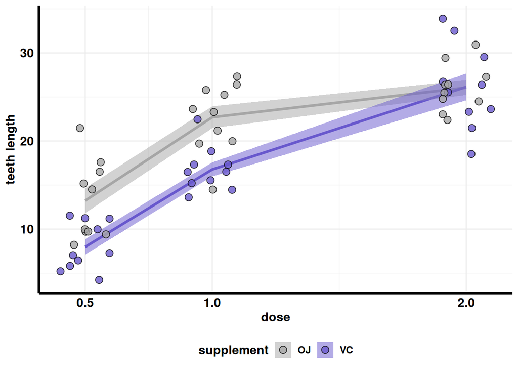

```r
ToothGrowth %>%
  ggplot(aes(x = dose, y = len)) +
  stat_summary(geom = "line",
               fun = mean,
               aes(group = supp, color = supp),
               linewidth = 1.2) +
  stat_summary(geom = "ribbon",
               fun.data = mean_se,
               aes(group = supp,
                   fill = supp),
               alpha = 0.5) +
  geom_point(aes(fill = supp),
             position = position_jitter(0.1, seed = 666),
             alpha = 0.8,
             size = 3,
             shape = 21,
             color = "black") +
  scale_fill_manual(values = wisteria[c(1, 7)]) +
  scale_color_manual(values = wisteria[c(1, 7)]) +
  scale_x_continuous(breaks = c(0.5, 1, 2)) +
  labs(x = "dose",
       y = "teeth length",
       fill = "supplement",
       color = "supplement") +
  guides(color = "none") +
  theme_minimal() +
  theme(
    axis.line = element_line(linewidth = 1.2), # add axis line back
    text = element_text(size = 12, color = "black", face = "bold"), # make text clearer and darker
    axis.text = element_text(size = 12, color = "black", face = "bold"),
    legend.position = "bottom" # move legend to bottom
    )
```

In `theme()`, you can put `legend.position = "bottom"`. You can also put `"top"`, `"right"` or `"left"`.

The more fancy thing is to move legend inside the graph area. How to do that?

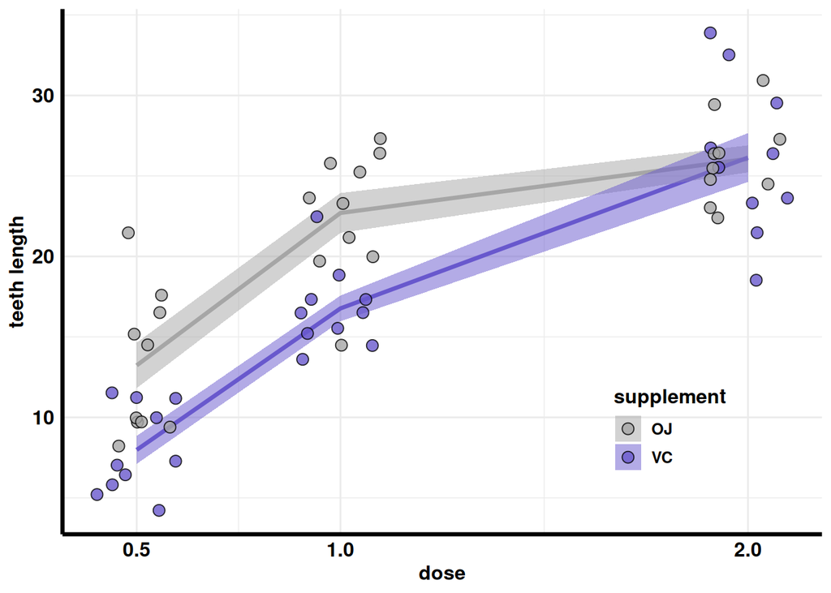

```r
ToothGrowth %>%
  ggplot(aes(x = dose, y = len)) +
  stat_summary(geom = "line",
               fun = mean,
               aes(group = supp, color = supp),
               linewidth = 1.2) +
  stat_summary(geom = "ribbon",
               fun.data = mean_se,
               aes(group = supp,
                   fill = supp),
               alpha = 0.5) +
  geom_point(aes(fill = supp),
             position = position_jitter(0.1, seed = 666),
             alpha = 0.8,
             size = 3,
             shape = 21,
             color = "black") +
  scale_fill_manual(values = wisteria[c(1, 7)]) +
  scale_color_manual(values = wisteria[c(1, 7)]) +
  scale_x_continuous(breaks = c(0.5, 1, 2)) +
  labs(x = "dose",
       y = "teeth length",
       fill = "supplement",
       color = "supplement") +
  guides(color = "none") +
  theme_minimal() +
  theme(
    axis.line = element_line(linewidth = 1.2), # add axis line back
    text = element_text(size = 12, color = "black", face = "bold"), # make text clearer and darker
    axis.text = element_text(size = 12, color = "black", face = "bold"),
    legend.position = "inside",
    legend.position.inside = c(0.8, 0.2) # move legend to inside graph area
    )
```

In `legend.position.inside = c(x, y)` (after setting `legend.position = "inside"`), you manually adjust where the legend will show up. For example `c(1, 1)` means upper right corner of the graph area, and `c(1, 0)` means the lower right corner of the graph area.

Now the legend is in the graph area. This is nice because now the legend doesn’t take up extra space.

One last adjustment you can do is change the number of rows and column of the legend. Now we have two rows, one column. What if I want one row and two columns?

We’ll use guides again.

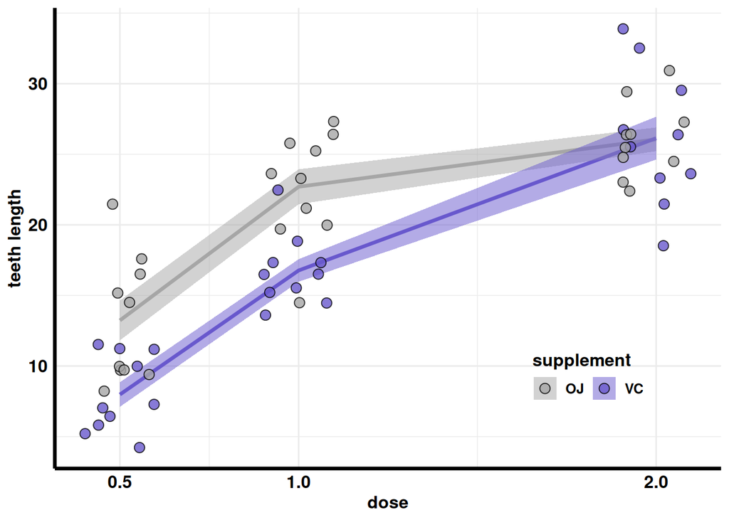

```r
ToothGrowth %>%
  ggplot(aes(x = dose, y = len)) +
  stat_summary(geom = "line",
               fun = mean,
               aes(group = supp, color = supp),
               linewidth = 1.2) +
  stat_summary(geom = "ribbon",
               fun.data = mean_se,
               aes(group = supp,
                   fill = supp),
               alpha = 0.5) +
  geom_point(aes(fill = supp),
             position = position_jitter(0.1, seed = 666),
             alpha = 0.8,
             size = 3,
             shape = 21,
             color = "black") +
  scale_fill_manual(values = wisteria[c(1, 7)]) +
  scale_color_manual(values = wisteria[c(1, 7)]) +
  scale_x_continuous(breaks = c(0.5, 1, 2)) +
  labs(x = "dose",
       y = "teeth length",
       fill = "supplement",
       color = "supplement") +
  guides(color = "none") +
  guides(fill = guide_legend(nrow = 1, ncol = 2)) + # set fill legend to 1 row 2 columns.
  theme_minimal() +
  theme(
    axis.line = element_line(linewidth = 1.2), # add axis line back
    text = element_text(size = 12, color = "black", face = "bold"), # make text clearer and darker
    axis.text = element_text(size = 12, color = "black", face = "bold"),
    legend.position = "inside",
    legend.position.inside = c(0.8, 0.2) # move legend to inside graph area
    )
```

This line `guides(fill = guide_legend(nrow = N))` is very useful when you have limited space and a lot of legend items. It also works as `guides(color = guide_legend(nrow = N))` if you need to arrange color legends. Again, think about the difference between fill and color.

# Faceting

faceting is very important when you have a factorial design. In this experiment, we have supp as a factor, and dose as another factor. So this is a factorial design. Faceting allows you and readers to focus on the true comparison of interest.

Let’s say we are interested in comparing the effect of each supp across different doses…

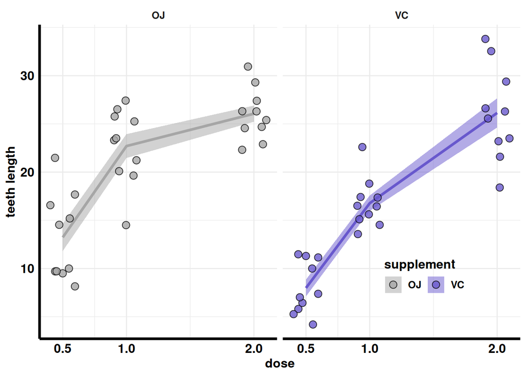

```r
ToothGrowth %>%
  ggplot(aes(x = dose, y = len)) +
  facet_grid(. ~ supp) + #see comments after plot for explanations
  stat_summary(geom = "line",
               fun = mean,
               aes(group = supp, color = supp),
               linewidth = 1.2) +
  stat_summary(geom = "ribbon",
               fun.data = mean_se,
               aes(group = supp,
                   fill = supp),
               alpha = 0.5) +
  geom_point(aes(fill = supp),
             position = position_jitter(0.1, seed = 666),
             alpha = 0.8,
             size = 3,
             shape = 21,
             color = "black") +
  scale_fill_manual(values = wisteria[c(1, 7)]) +
  scale_color_manual(values = wisteria[c(1, 7)]) +
  scale_x_continuous(breaks = c(0.5, 1, 2)) +
  labs(x = "dose",
       y = "teeth length",
       fill = "supplement",
       color = "supplement") +
  guides(color = "none") +
  guides(fill = guide_legend(nrow = 1, ncol = 2)) +
  theme_minimal() +
  theme(
    axis.line = element_line(linewidth = 1.2), # add axis line back
    text = element_text(size = 12, color = "black", face = "bold"), # make text clearer and darker
    axis.text = element_text(size = 12, color = "black", face = "bold"),
    legend.position = "inside",
    legend.position.inside = c(0.8, 0.2) # move legend to inside graph area
    )
```

Now it makes two plots. The facet syntax works like this: `facet_grid(row ~ column)` We are using supp as columns, and only 1 row, so `facet_grid(. ~ supp)`. The `.` before the `~` is just a space holder.

You can increase the panel spacing too.

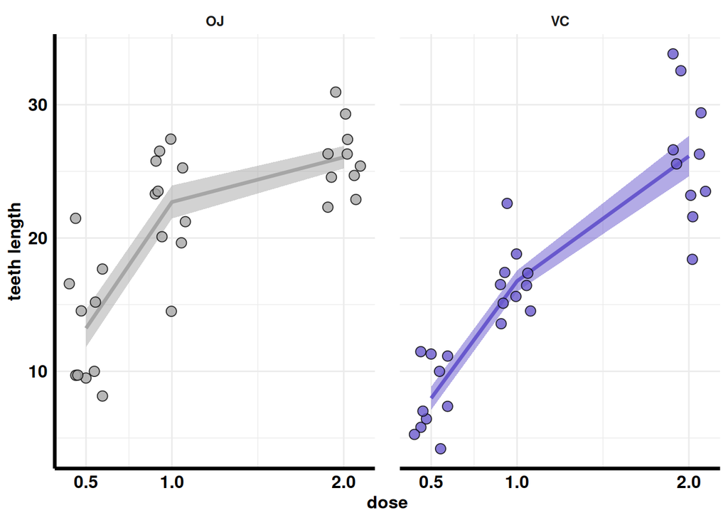

```r
ToothGrowth %>%
  ggplot(aes(x = dose, y = len)) +
  facet_grid(. ~ supp) +
  stat_summary(geom = "line",
               fun = mean,
               aes(group = supp, color = supp),
               linewidth = 1.2) +
  stat_summary(geom = "ribbon",
               fun.data = mean_se,
               aes(group = supp,
                   fill = supp),
               alpha = 0.5) +
  geom_point(aes(fill = supp),
             position = position_jitter(0.1, seed = 666),
             alpha = 0.8,
             size = 3,
             shape = 21,
             color = "black") +
  scale_fill_manual(values = wisteria[c(1, 7)]) +
  scale_color_manual(values = wisteria[c(1, 7)]) +
  scale_x_continuous(breaks = c(0.5, 1, 2)) +
  labs(x = "dose",
       y = "teeth length",
       fill = "supplement",
       color = "supplement") +
  guides(color = "none") +
  guides(fill = guide_legend(nrow = 1, ncol = 2)) +
  theme_minimal() +
theme(
    axis.line = element_line(linewidth = 1.2), # add axis line back
    text = element_text(size = 12, color = "black", face = "bold"), # make text clearer and darker
    axis.text = element_text(size = 12, color = "black", face = "bold"),
    legend.position = "none", # move legend to inside graph area
    panel.spacing = unit(1.2, "lines") #make 1.2 lines of spacing between the subplots (panels)
    )
```

Panel spacing was increased using `theme(panel.spacing = unit(1.2, "lines"))`.

Note that this time the legend is redundant with the panel label, so I turn it off using `legend.position = "none"` in `theme()`. Great!

But now say I am actually interested in comparing between supp at each dose, what do I do? We’ll need `facet_grid(. ~ dose)`, no?

```
## `geom_line()`: Each group consists of only one observation.
## ℹ Do you need to adjust the group aesthetic?
## `geom_line()`: Each group consists of only one observation.
## ℹ Do you need to adjust the group aesthetic?
## `geom_line()`: Each group consists of only one observation.
## ℹ Do you need to adjust the group aesthetic?
```

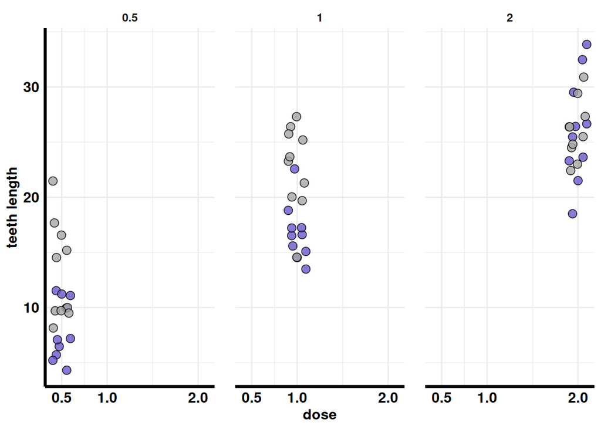

```r
ToothGrowth %>%
  ggplot(aes(x = dose, y = len)) +
  facet_grid(. ~ dose) +  #change to ~ dose
  stat_summary(geom = "line",
               fun = mean,
               aes(group = supp, color = supp),
               linewidth = 1.2) +
  stat_summary(geom = "ribbon",
               fun.data = mean_se,
               aes(group = supp,
                   fill = supp),
               alpha = 0.5) +
  geom_point(aes(fill = supp),
             position = position_jitter(0.1, seed = 666),
             alpha = 0.8,
             size = 3,
             shape = 21,
             color = "black") +
  scale_fill_manual(values = wisteria[c(1, 7)]) +
  scale_color_manual(values = wisteria[c(1, 7)]) +
  scale_x_continuous(breaks = c(0.5, 1, 2)) +
  labs(x = "dose",
       y = "teeth length",
       fill = "supplement",
       color = "supplement") +
  guides(color = "none") +
  guides(fill = guide_legend(nrow = 1, ncol = 2)) +
  theme_minimal() +
  theme(
    axis.line = element_line(linewidth = 1.2), # add axis line back
    text = element_text(size = 12, color = "black", face = "bold"), # make text clearer and darker
    axis.text = element_text(size = 12, color = "black", face = "bold"),
    legend.position = "none", # move legend to inside graph area
    panel.spacing = unit(1.2, "lines") #make 1.2 lines of spacing between the subplots (panels)
    )
```

Now there is a problem. The lines and ribbons are gone. That’s because in each panel, there is only one dose. There is nothing to connect. And the x axis is redundant with the panel. So what we really need is to put supp on x axis instead.

```
## Ignoring unknown labels:
## • colour : "supplement"
```

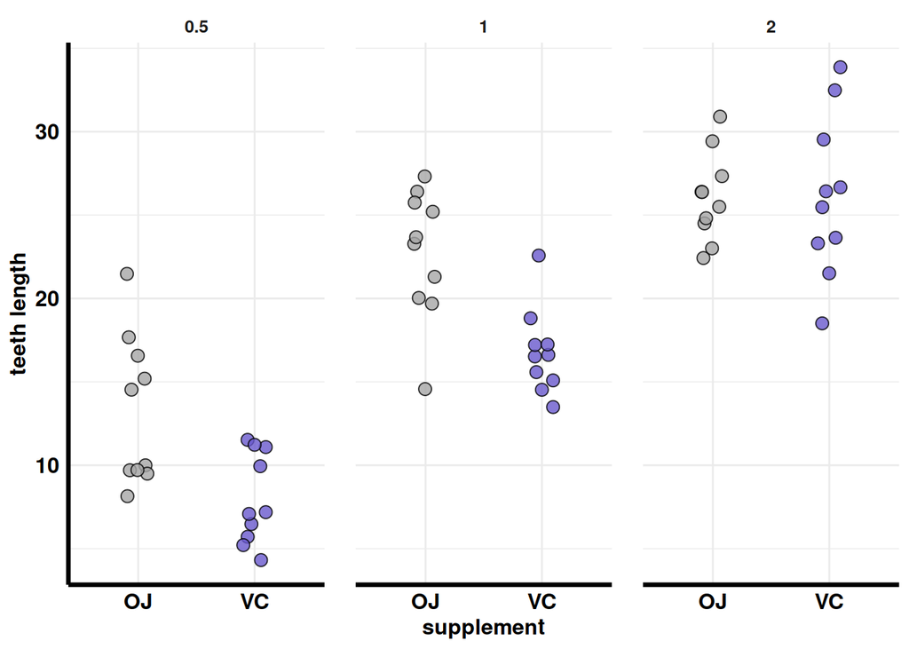

```r
ToothGrowth %>%
  ggplot(aes(x = supp, y = len)) +
  facet_grid(. ~ dose) +
  geom_point(aes(fill = supp),
             position = position_jitter(0.1, seed = 666),
             alpha = 0.8,
             size = 3,
             shape = 21,
             color = "black") +
  scale_fill_manual(values = wisteria[c(1, 7)]) +
  scale_color_manual(values = wisteria[c(1, 7)]) +
  #scale_x_continuous(breaks = c(0.5, 1, 2)) +  remove this. this time x axis is discrete
  labs(x = "supplement",  #now x = supplment
       y = "teeth length",
       fill = "supplement",
       color = "supplement") +
  guides(color = "none") +
  guides(fill = guide_legend(nrow = 1, ncol = 2)) +
  theme_minimal() +
  theme(
    axis.line = element_line(linewidth = 1.2), # add axis line back
    text = element_text(size = 12, color = "black", face = "bold"), # make text clearer and darker
    axis.text = element_text(size = 12, color = "black", face = "bold"),
    legend.position = "none", # move legend to inside graph area
    panel.spacing = unit(1.2, "lines") #make 1.2 lines of spacing between the subplots (panels)
    )
```

There is no numeric trend over the x variable, so I removed the ribbon and line. But I can still add the errorbars back.

```
## Ignoring unknown labels:
## • colour : "supplement"
```

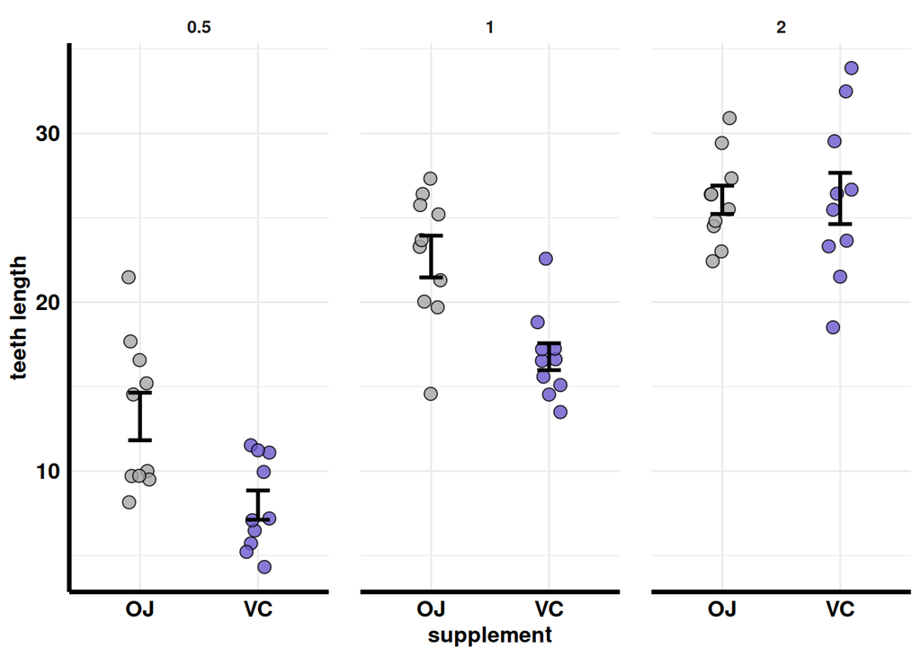

```r
ToothGrowth %>%
  ggplot(aes(x = supp, y = len)) +
  facet_grid(. ~ dose) +
  geom_point(aes(fill = supp),
             position = position_jitter(0.1, seed = 666),
             alpha = 0.8,
             size = 3,
             shape = 21,
             color = "black") +
  stat_summary(geom = "errorbar", #draw errorbars
               width = 0.2, linewidth = 1,
               aes(group = supp), #one bar per supp per dose
               fun.data = mean_se) +   #errorbar base on standard error (SE)
  scale_fill_manual(values = wisteria[c(1, 7)]) +
  scale_color_manual(values = wisteria[c(1, 7)]) +
  labs(x = "supplement",  #now x = supplment
       y = "teeth length",
       fill = "supplement",
       color = "supplement") +
  guides(color = "none") +
  guides(fill = guide_legend(nrow = 1, ncol = 2)) +
  theme_minimal() +
  theme(
    axis.line = element_line(linewidth = 1.2), # add axis line back
    text = element_text(size = 12, color = "black", face = "bold"), # make text clearer and darker
    axis.text = element_text(size = 12, color = "black", face = "bold"),
    legend.position = "none", # move legend to inside graph area
    panel.spacing = unit(1.2, "lines") #make 1.2 lines of spacing between the subplots (panels)
    )
```

Pretty good. There is one problem. “OJ” and “VC” text appear multiple times. We can turn them off and only show the legend.

```
## Ignoring unknown labels:
## • colour : "supplement"
```

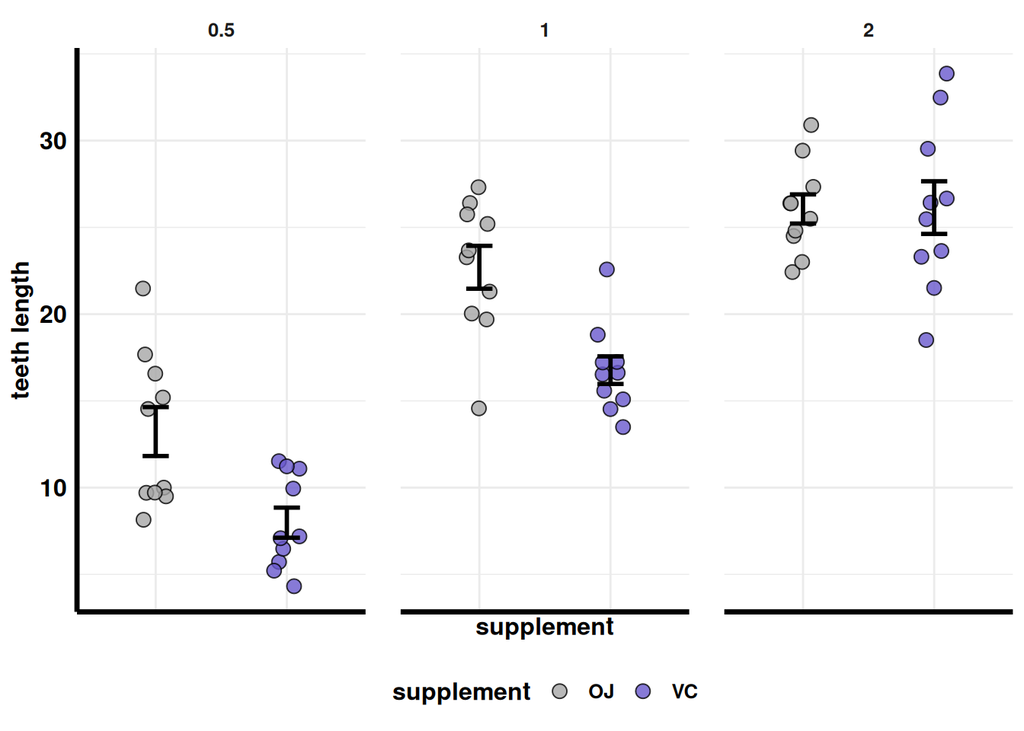

```r
ToothGrowth %>%
  ggplot(aes(x = supp, y = len)) +
  facet_grid(. ~ dose) +
  geom_point(aes(fill = supp),
             position = position_jitter(0.1, seed = 666),
             alpha = 0.8,
             size = 3,
             shape = 21,
             color = "black") +
  stat_summary(geom = "errorbar",
               width = 0.2, linewidth = 1,
               aes(group = supp),
               fun.data = mean_se) +
  scale_fill_manual(values = wisteria[c(1, 7)]) +
  scale_color_manual(values = wisteria[c(1, 7)]) +
  scale_x_discrete(labels = NULL) + #turn off x axis text using labels = NULL
  labs(x = "supplement",
       y = "teeth length",
       fill = "supplement",
       color = "supplement") +
  guides(color = "none") +
  guides(fill = guide_legend(nrow = 1, ncol = 2)) +
  theme_minimal() +
  theme(
    axis.line = element_line(linewidth = 1.2), # add axis line back
    text = element_text(size = 12, color = "black", face = "bold"), # make text clearer and darker
    axis.text = element_text(size = 12, color = "black", face = "bold"),
    legend.position = "bottom", # move legend to inside graph area
    panel.spacing = unit(1.2, "lines") #make 1.2 lines of spacing between the subplots (panels)
    )
```

Now just a couple final touches. Note that the text “supplement” appears twice, and dose appears none. We can put the panel labels to the bottom, and switch the x axis label to dose instead.

```
## Ignoring unknown labels:
## • colour : "supplement"
```

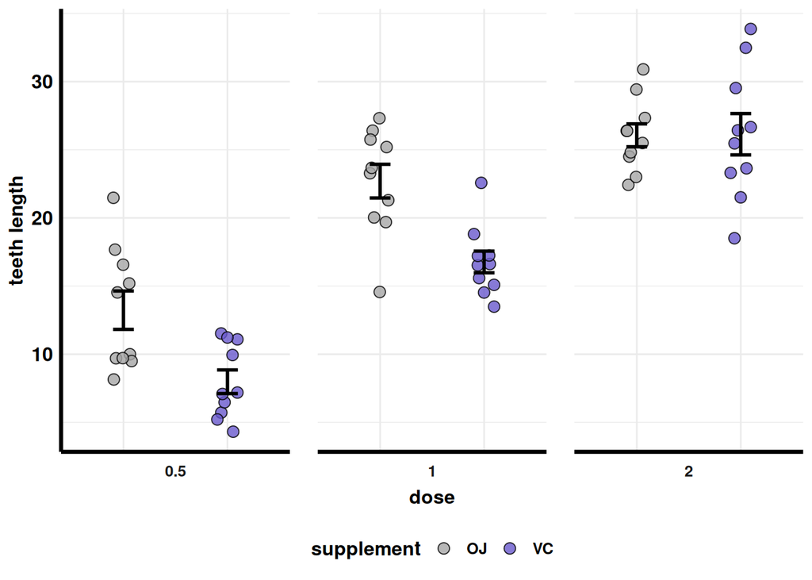

```r
ToothGrowth %>%
  ggplot(aes(x = supp, y = len)) +
  facet_grid(. ~ dose, switch = "x") + #switch = "x" puts x panel labels to the bottom instead of top
  geom_point(aes(fill = supp),
             position = position_jitter(0.1, seed = 666),
             alpha = 0.8,
             size = 3,
             shape = 21,
             color = "black") +
  stat_summary(geom = "errorbar",
               width = 0.2, linewidth = 1,
               aes(group = supp),
               fun.data = mean_se) +
  scale_fill_manual(values = wisteria[c(1, 7)]) +
  scale_color_manual(values = wisteria[c(1, 7)]) +
  scale_x_discrete(labels = NULL) +
  labs(x = "dose",  #now x is dose again
       y = "teeth length",
       fill = "supplement",
       color = "supplement") +
  guides(color = "none") +
  guides(fill = guide_legend(nrow = 1, ncol = 2)) +
  theme_minimal() +
  theme(
    axis.line = element_line(linewidth = 1.2), # add axis line back
    text = element_text(size = 12, color = "black", face = "bold"), # make text clearer and darker
    axis.text = element_text(size = 12, color = "black", face = "bold"),
    legend.position = "bottom", # move legend to inside graph area
    panel.spacing = unit(1.2, "lines"), #make 1.2 lines of spacing between the subplots (panels)
    strip.placement = "outside"
    )
```

Now it really looks like dose is x axis, but in fact it is the faceting factor.

Congratulations! You have produced a publication quality plot!

I think this is the best plot we can make for faceting by dose. The best practice of plotting is always identify the comparison of interest, remove redundant and unnecessary elements, try to make it as pretty as you can, and be clear on what you want to show.

# Exercise - Now time for you to try

Let’s use the R built-in dataset CO2 as example: Ref: Potvin, C., Lechowicz, M. J. and Tardif, S. (1990), Ecology, 71, 1389–1400.

```r
head(CO2)
```

```
##   Plant   Type  Treatment conc uptake
## 1   Qn1 Quebec nonchilled   95   16.0
## 2   Qn1 Quebec nonchilled  175   30.4
## 3   Qn1 Quebec nonchilled  250   34.8
## 4   Qn1 Quebec nonchilled  350   37.2
## 5   Qn1 Quebec nonchilled  500   35.3
## 6   Qn1 Quebec nonchilled  675   39.2
```

```r
str(CO2)
```

```
## Classes 'nfnGroupedData', 'nfGroupedData', 'groupedData' and 'data.frame':   84 obs. of  5 variables:
##  $ Plant    : Ord.factor w/ 12 levels "Qn1"<"Qn2"<"Qn3"<..: 1 1 1 1 1 1 1 2 2 2 ...
##  $ Type     : Factor w/ 2 levels "Quebec","Mississippi": 1 1 1 1 1 1 1 1 1 1 ...
##  $ Treatment: Factor w/ 2 levels "nonchilled","chilled": 1 1 1 1 1 1 1 1 1 1 ...
##  $ conc     : num  95 175 250 350 500 675 1000 95 175 250 ...
##  $ uptake   : num  16 30.4 34.8 37.2 35.3 39.2 39.7 13.6 27.3 37.1 ...
##  - attr(*, "formula")=Class 'formula'  language uptake ~ conc | Plant
##   .. ..- attr(*, ".Environment")=<environment: R_EmptyEnv>
##  - attr(*, "outer")=Class 'formula'  language ~Treatment * Type
##   .. ..- attr(*, ".Environment")=<environment: R_EmptyEnv>
##  - attr(*, "labels")=List of 2
##   ..$ x: chr "Ambient carbon dioxide concentration"
##   ..$ y: chr "CO2 uptake rate"
##  - attr(*, "units")=List of 2
##   ..$ x: chr "(uL/L)"
##   ..$ y: chr "(umol/m^2 s)"
```

Task: produce a plot that includes the info for Type and Treatment, with uptake on Y axis. Let’s say we are interested in the effect of “Treatment” in each Type.

Hint:

1. What should be on the x axis?
2. What variable do you color or fill with?
3. What faceting layout do you want to use?

Use the format:

CO2 %>% ggplot(aes(x = ???, y = uptake)) + facet_grid(??? ~ ???) + geom_point(aes()) + stat_summary(geom = errorbar) + scale_color_manual() + scale_fill_manual() + scale_…_…. + labs() + guides() + theme_minimal() + theme(legend.position = …) + theme(axis.line = element_line(linewidth = 1.2)) + theme(text = element_text(size = 12, color = “black”, face = “bold”)) + theme(axis.text = element_text(size = 12, color = “black”, face = “bold”))

Now try to make the best plot you can!

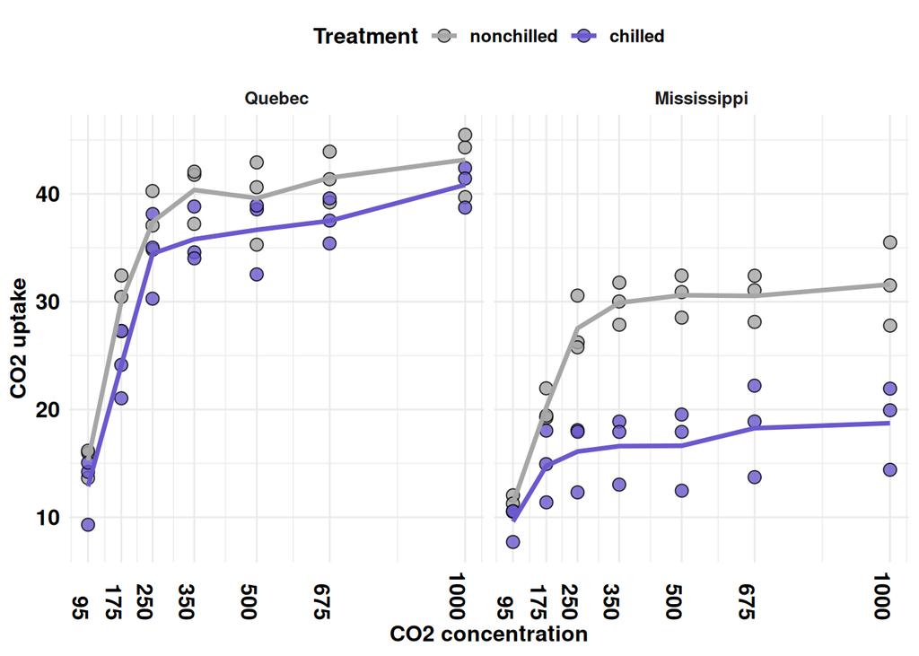

```r
conc_levels <- CO2$conc %>% unique %>% sort()
CO2 %>%
  ggplot(aes(x = conc, y = uptake)) +
  facet_grid(~ Type) +
  geom_point(aes(fill = Treatment),
             position = position_jitter(0.3, seed = 666),
             alpha = 0.8,
             size = 3,
             shape = 21,
             color = "black") +
    stat_summary(geom = "line",
               fun = mean,
               aes(group = Treatment, color = Treatment),
               linewidth = 1.2) +
    #stat_summary(geom = "errorbar",
               #width = 0.2, linewidth = 1,
               #aes(group = Treatment),
               #fun.data = mean_se) +
  scale_fill_manual(values = wisteria[c(1, 7)]) +
  scale_color_manual(values = wisteria[c(1, 7)]) +
  #scale_..._.... +
  scale_x_continuous(breaks = conc_levels) +
  labs(x = "CO2 concentration",
       y = "CO2 uptake",
       fill = "Treatment",
       color = "Treatment") +
  #guides(color = "none") +
  #guides(fill = guide_legend(nrow = 1, ncol = 2))
  #labs() +
  #guides() +
  theme_minimal() +
  theme(legend.position = "top") +
  #theme(axis.line = element_line(linewidth = 1.2)) +
  theme(text = element_text(size = 12, color = "black", face = "bold")) + theme(axis.text = element_text(size = 12, color = "black", face = "bold")) +
  theme(axis.text.x = element_text(angle = -90, vjust = 1, hjust = 1))
```

# Exercise 2 - Something fun!

Let’s use the Pokemon data set from https://www.kaggle.com/datasets/abcsds/pokemon?resource=download.

```r
 Pokemon <- read.csv("https://raw.githubusercontent.com/johnshorter/TeachingData/main/Pokemon.csv", stringsAsFactors = FALSE)

 Pokemon2 <- subset(Pokemon, Type.1 =='Water' | Type.1 =='Fire'| Type.1 =='Grass')
 Pokemon2 <- subset(Pokemon2, Generation =='1' | Generation == '2')
 #Don't worry about subsetting for now, we will go over this in a later lesson.
```

```r
 head(Pokemon2)
```

```
##   X.                  Name Type.1 Type.2 Total HP Attack Defense Sp..Atk
## 1  1             Bulbasaur  Grass Poison   318 45     49      49      65
## 2  2               Ivysaur  Grass Poison   405 60     62      63      80
## 3  3              Venusaur  Grass Poison   525 80     82      83     100
## 4  3 VenusaurMega Venusaur  Grass Poison   625 80    100     123     122
## 5  4            Charmander   Fire          309 39     52      43      60
## 6  5            Charmeleon   Fire          405 58     64      58      80
##   Sp..Def Speed Generation Legendary
## 1      65    45          1     FALSE
## 2      80    60          1     FALSE
## 3     100    80          1     FALSE
## 4     120    80          1     FALSE
## 5      50    65          1     FALSE
## 6      65    80          1     FALSE
```

```r
 str(Pokemon2)
```

```
## 'data.frame':    93 obs. of  13 variables:
##  $ X.        : int  1 2 3 3 4 5 6 6 6 7 ...
##  $ Name      : chr  "Bulbasaur" "Ivysaur" "Venusaur" "VenusaurMega Venusaur" ...
##  $ Type.1    : chr  "Grass" "Grass" "Grass" "Grass" ...
##  $ Type.2    : chr  "Poison" "Poison" "Poison" "Poison" ...
##  $ Total     : int  318 405 525 625 309 405 534 634 634 314 ...
##  $ HP        : int  45 60 80 80 39 58 78 78 78 44 ...
##  $ Attack    : int  49 62 82 100 52 64 84 130 104 48 ...
##  $ Defense   : int  49 63 83 123 43 58 78 111 78 65 ...
##  $ Sp..Atk   : int  65 80 100 122 60 80 109 130 159 50 ...
##  $ Sp..Def   : int  65 80 100 120 50 65 85 85 115 64 ...
##  $ Speed     : int  45 60 80 80 65 80 100 100 100 43 ...
##  $ Generation: int  1 1 1 1 1 1 1 1 1 1 ...
##  $ Legendary : logi  FALSE FALSE FALSE FALSE FALSE FALSE ...
```

Task: produce a plot that compares speed of fire, grass, and water pokemon from generations 1 and 2. Let’s keep it simple and use only the primary type. (Type.1 column)

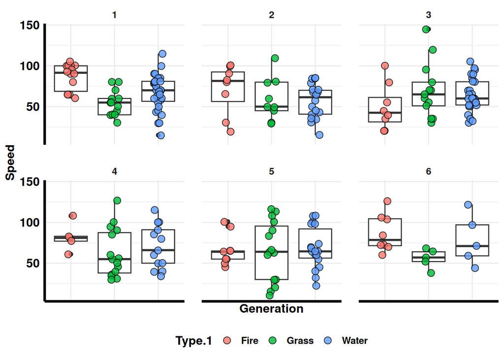

```r
Pokemon %>% filter(Type.1 %in% c('Fire', 'Grass', 'Water')) %>%
  ggplot(aes(x = Type.1, y = Speed)) +
  facet_wrap( ~ Generation, nrow = 2) +
  theme(axis.title.x = element_blank()) +
  #facet_grid(. ~ Generation) +
  geom_boxplot() +
  geom_point(aes(fill = Type.1),
             position = position_jitter(0.1, seed = 666),
             alpha = 0.8,
             size = 3,
             shape = 21,
             color = "black") +
  #stat_summary(geom = "errorbar",
               #width = 0.2, linewidth = 1,
               #aes(group = Type.1),
               #fun.data = mean_se) +
  #scale_fill_manual(values = wisteria[c(1, 7)]) +
  #scale_color_manual(values = wisteria[c(1, 7)]) +
  scale_x_discrete(labels = NULL) +
  labs(x = "Generation") +
  #     y = "teeth length",
  #     fill = "supplement",
  #     color = "supplement") +
  guides(color = "none") +
  #guides(fill = guide_legend(nrow = 1, ncol = 2)) +
  theme_minimal() +
  theme(
    axis.line = element_line(linewidth = 1.2), # add axis line back
    text = element_text(size = 12, color = "black", face = "bold"), # make text clearer and darker
    axis.text = element_text(size = 12, color = "black", face = "bold"),
    legend.position = "bottom", # move legend to inside graph area
    panel.spacing = unit(1.2, "lines"), #make 1.2 lines of spacing between the subplots (panels)
    strip.placement = "outside"
    )
```

## What to submit to Moodle

For this lesson, complete the exercises, then **Knit to HTML** and upload the HTML file to the Moodle exercise folder.

## Additional exercises

### Exercise 2 — Titles, labels, and caption

Create one ggplot and add: - Title - Subtitle - Caption (include data source or “built-in dataset”) - Axis labels with units (if relevant)

**Self-check:** all labels appear in the knitted HTML.

### Exercise 3 — Theme consistency

Apply a theme (e.g., `theme_bw()` or your preferred custom theme). Make 2 small improvements (font size, legend position, gridlines, etc.).

**Self-check:** the changes are visible; the plot is easier to read.

### Exercise 4 — Facets or grouping

Make a plot that uses either `facet_*()` or color/shape to show groups. Write 2 sentences on what the grouping adds.

**Self-check:** groups are clearly distinguishable and the legend is readable.

### Exercise 5 — Save a figure

Save one plot to file (e.g., `ggsave()`) with a sensible size.

**Self-check:** file is created; the saved figure is not tiny/blurry.